B_Spline Zero_Inflation Classification Logit

# Classification Tree & B Spline

### Description:

### mobileTrain.csv and mobileTest.csv contain features and price range for 1000 mobile phones. Mobile prices are categorized to the four classes; 0,1,2 and 3. The train data mobileTrain is used to fit a model and the test data mobileTest is used to validate a fitted model.

### The interest is building a good mobile price predictor using a machine learning technique.

```r
library(MASS); library(klaR); library(nnet);
```

```r
library(reshape2); library(ggplot2); library(e1071)
library(rpart); library(rpart.plot); library(rattle);
library(splines); library(glmnet); library(randomForest); library(kernlab); library(gbm); library(quantreg)
```

## Question 1

#### In the class, the three learning methods for tree based model were learned and, they were a classification tree, random forests and gradient boosting method. Our choice for performance measure is a precision and find the best classifier

```r
mobile.train <- read.csv(file='mobileTrain.csv',header=TRUE)
mobile.train$price_range = as.factor(mobile.train$price_range)
mobile.test <- read.csv(file='mobileTest.csv',header=TRUE)
mobile.test$price_range = as.factor(mobile.test$price_range)
```

### (a)

```r
#precision function
precision <- function(x.pred,x.obs){
  mx <- table(x.pred,x.obs)
  z=0
  for(i in 1:length(unique(x.obs))){
    z <- z+mx[i,i]/sum(mx[i,])
  }
  return(z/i)
}
```

```r
#classification tree
#The min cp value is reduced to 0.001 because with the default value, tree didn't grow big enough to show some sign of overfit.
set.seed(1234)
tree <- rpart(price_range ~. , data=mobile.train, method='class',cp=0.001)
tree$cptable
```

```
##             CP nsplit rel error    xerror       xstd
## 1  0.333793103      0 1.0000000 1.0000000 0.01947589
## 2  0.197241379      1 0.6662069 0.6662069 0.02179620
## 3  0.144827586      2 0.4689655 0.4882759 0.02085835
## 4  0.018965517      3 0.3241379 0.3434483 0.01886173
## 5  0.017931034      7 0.2482759 0.3296552 0.01860173
## 6  0.012413793      9 0.2124138 0.3020690 0.01803888
## 7  0.008275862     10 0.2000000 0.2620690 0.01711123
## 8  0.006896552     12 0.1834483 0.2482759 0.01675734
## 9  0.006206897     13 0.1765517 0.2455172 0.01668430
## 10 0.004137931     15 0.1641379 0.2482759 0.01675734
## 11 0.003678161     17 0.1558621 0.2468966 0.01672092
## 12 0.003448276     20 0.1448276 0.2482759 0.01675734
## 13 0.002068966     22 0.1379310 0.2606897 0.01707668
## 14 0.001379310     24 0.1337931 0.2634483 0.01714561
## 15 0.001000000     26 0.1310345 0.2662069 0.01721383
```

```r
tree.min <- prune(tree,cp=tree$cptable[which.min(tree$cptable[,4]),1])
tree.p <- precision(predict(tree.min,mobile.test,type='class'),mobile.test$price_range)
```

```r
#Random forests
set.seed(1234)
mobile.rf <- randomForest(price_range ~., data = mobile.train, importance=TRUE)
rf.p <- precision(predict(mobile.rf,mobile.test,type='class'),mobile.test$price_range)
```

```r
#Gradient boosting method
#the number of tree is increased to 2000 because the default value of 100 was too small.
set.seed(1234)
mobile.gbm <- gbm(price_range~., data = mobile.train, distribution='multinomial',shrinkage = 0.1, n.trees = 2000, cv.folds = 10)
mobile.gbm.perf = gbm.perf(mobile.gbm, method = "cv")
```

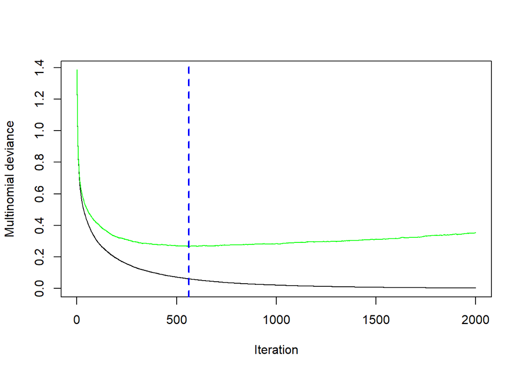

```r
#price range probabilities are computed.
p.pred = predict(mobile.gbm,mobile.test,type='response')
```

```
## Using 561 trees...
```

```r
#price range prediction is a range with the highest probability.
c.pred = as.factor(apply(p.pred[,,1],1,function(x) which.max(x))-1)

gbm.p <- precision(c.pred,mobile.test$price_range)
```

Alternatively classes can be predicted using random numbers. If you are on this path, the random forest will be the best classifier and (b) will should be answer for the random forest classifier.

```r
set.seed(1234)
#random numbers
nn=runif(nrow(mobile.test))
c.pred2=rep(0,nrow(mobile.test))
#class is chosen according to class probabilities.
for(i in 1:nrow(mobile.test)){ c.pred2[i]=sum(nn[i]>cumsum(p.pred[i,,1])) }
precision(as.factor(c.pred2),mobile.test$price_range)
```

```
## [1] 0.8494186
```

Let’s compare the precision.

```r
tree.p
```

```
## [1] 0.7992161
```

```r
rf.p
```

```
## [1] 0.8699349
```

```r
gbm.p
```

```
## [1] 0.8988407
```

Gradient boosting method yields the highest precision and, is the best classifier.

### (b)

#### Write the two most important variables in predicting a mobile price for your best learning method in (a).

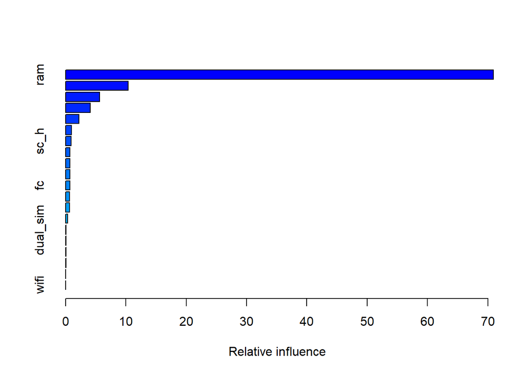

|  | var | rel.inf |
| --- | --- | --- |
| ram | ram | 70.92168174 |
| battery_power | battery_power | 10.38826148 |
| px_height | px_height | 5.64204552 |
| px_width | px_width | 4.09446578 |
| mobile_wt | mobile_wt | 2.22073194 |
| int_memory | int_memory | 0.99037723 |
| sc_h | sc_h | 0.94591806 |
| talk_time | talk_time | 0.74401305 |
| clock_speed | clock_speed | 0.74290839 |
| pc | pc | 0.70430756 |

[output cut: 10 more lines]

```r
#variable importance
summary(mobile.gbm)
```

ram and battery_power are the two most important variables. Splitting ram and battery_power spaces increase the biggest gain in classification tree.

### (c)

#### Repeat the analysis using a multinomial regression and characterize an expensive mobile phone using your multinomial regression.

```r
#Multinomial logistic regression
mobile.mn <- multinom(price_range~ ., data = mobile.train)
mobile.mn
```

```
## Call:
## multinom(formula = price_range ~ ., data = mobile.train)
##
## Coefficients:
##   (Intercept) battery_power      blue clock_speed  dual_sim        fc    four_g
## 1   -3405.354     0.9002125 -19.91115   -19.61421 -54.56989 -2.773676 -30.79350
## 2   -7497.991     1.6052089 -22.17667   -26.47433 -42.42538  1.079855 -38.26214
## 3  -14304.845     2.5190845 -38.89008   -41.10587 -20.30445  4.532942 -36.54930
##   int_memory      m_dep mobile_wt  n_cores         pc px_height  px_width
## 1  0.7361512 -89.098410 -1.107256 15.08311  1.1271690 0.4859991 0.4886499
## 2  3.3823105 -87.069850 -2.386441 26.55707  0.4935546 0.8459658 0.9626169
## 3  5.8041904  -4.362113 -4.776040 27.84909 -0.5526006 1.5033396 1.5022867
##        ram      sc_h       sc_w  talk_time   three_g touch_screen      wifi
## 1 1.420043  1.486381 -0.2521717 -8.0775779 -9.734687    -91.24004  18.31678
## 2 2.547451  4.746817 -6.1380393 -6.4022283  7.640764    -98.44721  18.34727
## 3 4.069746 13.265003 -5.7868776 -0.3526402 33.402243   -107.75272 -29.82446
##
## Residual Deviance: 3.761141
## AIC: 129.7611
```

The base level is price_range=0 (low cost). Positive coefficient means the corresponding price range probability increases with an input feature compared to the base level. Coefficients for batter_power, int_memory, n_cores, px_height, px_width and ram, sc_h are strictly positive and increased as a price range gets higher. Bigger battery power, bigger internal memory, more number of cores, bigger ram, larger screen height and larger pixel resolution in height/width increases a phone price.

[This is not required.] Coefficients for those variables increase with a price range. They are positive if a price range is higher than the based and negative for a lower price range. You may check this by changing a base level.

```r
mobile.train00=mobile.train
mobile.train00$price_range <- relevel(mobile.train00$price_range, ref = "1")
coef(multinom(price_range~ ., data = mobile.train00))
```

```
##   (Intercept) battery_power      blue clock_speed  dual_sim        fc    four_g
## 0    5971.681     -1.584966  73.54591   26.947485 115.81710  2.726349 43.063601
## 2   -6414.932      1.079935  19.95468    8.072286  29.12459  5.443965 -5.457234
## 3  -18061.709      2.646956 -26.59968  -22.937361  87.60287 12.583216 25.557698
##   int_memory      m_dep mobile_wt   n_cores        pc  px_height   px_width
## 0  -1.343144 159.631813  2.278544 -30.59029  3.107362 -0.8689467 -0.8193609
## 2   3.547035  -4.678716 -2.098399  14.77199  1.081550  0.5536870  0.7828193
## 3   8.341871 142.833422 -6.540650  16.38368 -2.897472  1.6937666  1.7199346
##         ram      sc_h      sc_w  talk_time   three_g touch_screen       wifi
## 0 -2.539399 -2.599739 -2.297226 13.0161209  9.741821    148.58945  -46.52951
## 2  1.801074  1.738423 -5.488148  0.8262202 30.167399    -27.88663  -49.82970
## 3  4.421409 17.767157 -7.412576  9.9961746 22.044297    -13.96031 -160.37357
```

```r
mobile.train00$price_range <- relevel(mobile.train00$price_range, ref = "2")
coef(multinom(price_range~ ., data = mobile.train00))
```

```
##   (Intercept) battery_power      blue clock_speed   dual_sim         fc
## 1    2444.149    -0.4139014  16.76216    3.071173 -10.133085 -2.5388537
## 0    4236.787    -0.8867258  30.53985   11.940323  -1.839276 -1.7232388
## 3   -3837.885     0.5170830 -13.69824   -6.196936   7.224301  0.6731403
##      four_g int_memory     m_dep  mobile_wt    n_cores          pc  px_height
## 1  8.058120  -1.646931 -13.92953  0.6870462  -7.467515  0.05565890 -0.2134835
## 0 26.574330  -1.717892  25.18251  1.3493752 -14.703000  0.67236515 -0.4824660
## 3  3.101776   1.348305  45.93818 -1.3571151   1.728081 -0.05445016  0.3713270
##     px_width        ram      sc_h      sc_w  talk_time    three_g touch_screen
## 1 -0.2853641 -0.6663632 -1.987191 3.5187260 -0.8304143 -20.144843    12.588278
## 0 -0.5388514 -1.4218747 -2.442763 4.3298573  2.3453333  -8.157698    49.956124
## 3  0.3172332  0.8546102  4.178348 0.4636235  3.6595140   4.043217     3.180857
##         wifi
## 1   8.467559
## 0  -7.108181
## 3 -34.780588
```

### (d)

#### Compare the precision of your best learning method in (a) and multinomial logistic regression in (c). What can we say about the underlying relationship between a price and covariates?

```r
precision(predict(mobile.mn,mobile.test,type='class'),mobile.test$price_range)
```

```
## [1] 0.9535133
```

A higher precision is obtained from a multinomial logistic regression. This means linear boundaries in the input space between price ranges.

### (e)

#### rite why both LDA and QDA are not suitable classification methods for this data.

Gaussian distribution assumption is violated because of binary covariates in the mobile data.

## Question 2

#### Description:

#### TricepsSkinfold.csv are derived from an anthropometric study of 892 females under 50 years in three Gambian villages in West Africa.

###### Source: Cole T.J., Green P.J. (1992). Smoothing reference centile curves: the LMS method and penalized likelihood. Statistics in medicine, 11(10): 1305-1319.

#### The interest is predicting a logged value for triceps skinfold thickness given an age.

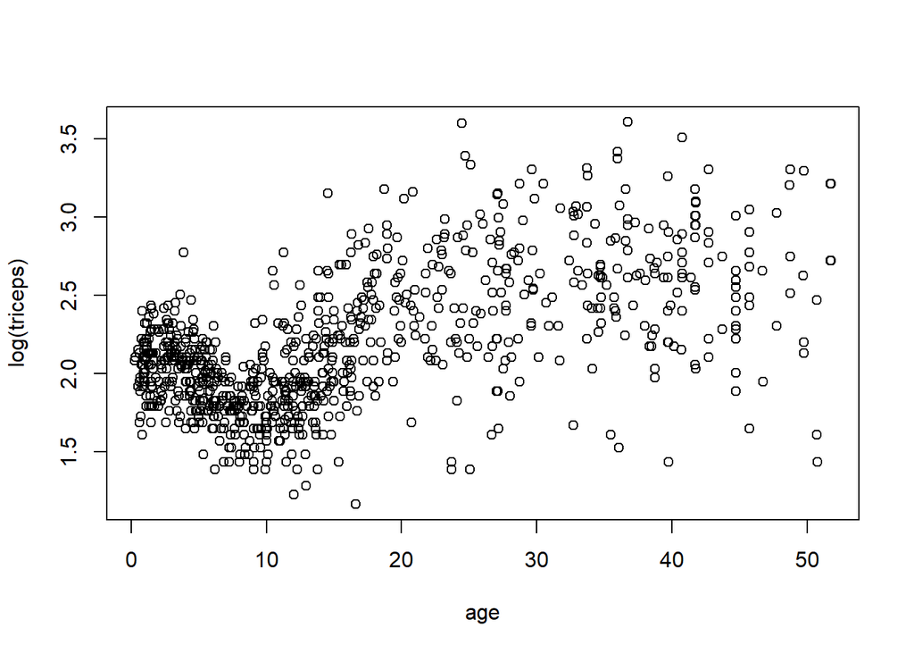

```r
triceps <- read.csv(file='TricepsSkinfold.csv',header=TRUE)
plot(log(triceps)~age,triceps)
```

### (a)

#### As it is seen in the above scatter plot, logged values for triceps skinfold thickness are not linear with ages. A linear regression using a B-spline of the order 3 is considered and, a range of possible number of knots is [0, 20].

#### Find the number of knots minimizing the cross validation error using 10 folders.

```r
set.seed(1234)

n.knots=c(0:20)
cv.triceps=rep(0,length(n.knots))
ii=rep(c(1:10),90); ii=ii[1:892]

for(j in 1:length(n.knots)){ for(i in 1:10){
  t.bs=predict(lm(log(triceps)~bs(age,df=n.knots[j]+3,Boundary.knots=c(0.2,52)),data=triceps[-which(ii==i),]),newdata=triceps[which(ii==i),])
  cv.triceps[j]=cv.triceps[j]+mean((log(triceps$triceps[which(ii==i)])-t.bs)^2)
}}
#no of knots minimizing the cv error
min.knots = n.knots[which.min(cv.triceps)]
min.knots
```

```
## [1] 11
```

### (b)

#### Using your choice of number of knots in (a), plot the logged values for triceps skinfold thickness prediction against ages with confidence intervals.

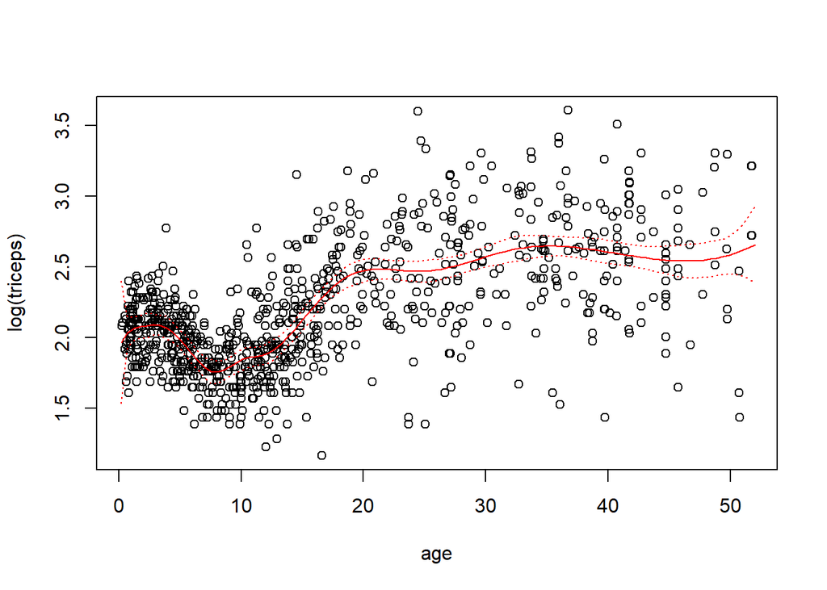

```r
x0 = data.frame(age=seq(from=0.2,to=52,length.out=100))

pred.triceps2 <- predict(lm(log(triceps)~bs(age,df=min.knots+3,Boundary.knots=c(0.2,52)),data=triceps),newdata=x0,interval = 'confidence')

plot(log(triceps)~age,triceps); lines(x0$age,pred.triceps2[,1],col='red'); lines(x0$age,pred.triceps2[,2],lty=3,col='red'); lines(x0$age,pred.triceps2[,3],lty=3,col='red');
```

### (c)

#### Using your choice of number of knots in (a), fit regression models targeting the 0.1, 0.5 and 0.9 quantiles of tricepts skinfold thickness in log. i.e., quantile regression.

#### Display the expected 0.1, 0.5 and 0.9th quantiles of triceps skinfold thickness in log against ages in a single figure.

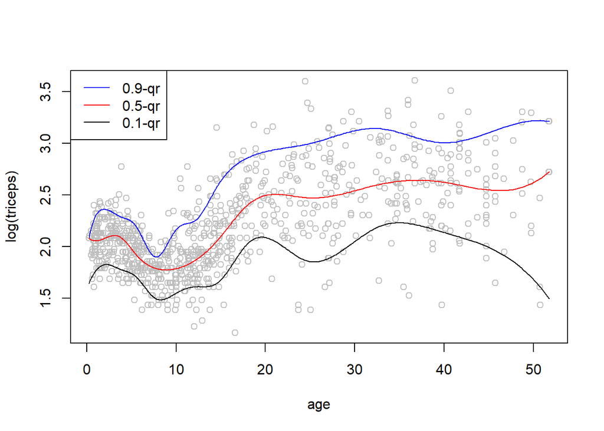

```r
rqfit10 <- rq(log(triceps) ~ bs(age,df=min.knots+3,Boundary.knots=c(0.2,52)),data=triceps,tau=0.1)
rqfit50 <- rq(log(triceps) ~ bs(age,df=min.knots+3,Boundary.knots=c(0.2,52)),data=triceps,tau=0.5)
rqfit90 <- rq(log(triceps) ~ bs(age,df=min.knots+3,Boundary.knots=c(0.2,52)),data=triceps,tau=0.9)
pred.q90 = predict(rqfit90,triceps); pred.q50 = predict(rqfit50,triceps); pred.q10 = predict(rqfit10,triceps)

i.age=sort(triceps$age,index.return=TRUE)
plot(log(triceps)~age,triceps,col='grey')
lines(triceps$age[i.age$ix],pred.q90[i.age$ix],col='blue')
lines(triceps$age[i.age$ix],pred.q50[i.age$ix],col='red')
lines(triceps$age[i.age$ix],pred.q10[i.age$ix])
legend("topleft",col=c('blue','red','black'),lty=1,legend=c("0.9-qr","0.5-qr","0.1-qr"))
```